# EB3I n1 2025 scRNAseq - **PRE-PROCESSING (I)** - Load a count matrix, empty droplets & ambient RNA filtering

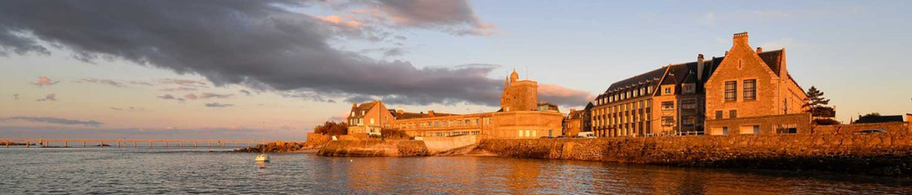

# 1 PREAMBLE

## 1.1 Purpose of this session

This file describes the different steps to perform the **first part** of the **single cell RNAseq** data analysis training course for the **EB3I n1 2025**, covering these steps :

- **Load** a single cell raw counts **matrix**
- **Remove** barcodes from **empty droplets**
- **Estimate** and remove **ambient RNA** contamination *(“soup”)*

## 1.2 An important notice

- These early (but mandatory) steps of the analysis are not covered by the renowned, higher-level analysis frameworks like **Seurat** nor **scran/scater**.
- Thus, we will write/use a certain amount of **lines of code**, some of which of a higher complexity for R beginners.
- **Newcomer, do not fear** !
  - While you are **welcome to try** writing some by yourself, depending on your R knowledge and self-confidence in it …
  - … you do not have to know **how** these code work …
  - … thus you **should not feel ashamed** copy-pasting the pre-written code hereafter …
  - … but in both cases, please try **your best understanding** **what** these code do, and even more, **why** !
  - In this purpose, you may use whatever **help** you can **by** **searching**.

## 1.3 What to run ?

- This training presentation, written in Rmarkdown, contains **many** chunks ( = code blocks)
- You **do not have to** run them all !
- Chunks follow a **color code** :

### 1.3.1 Chunks you **ARE** expected to run :

```r
# chunk_run

## Example of chunk to run
getwd()
```

**Show output**

```
[1] "/shared/projects/2538_eb3i_n1_2025/atelier_scrnaseq/RMD/Preproc.1"
```

### 1.3.2 Chunks you **ARE NOT** expected to run

Hopefully, we will demo them. You may run them by yourself, young padawan, but if you get late or worst, break something, *you*’ll be the one to blame !

```r
# chunk_demo

## Example of chunk to NOT run
utils::sessionInfo()
```

### 1.3.3 Questions

Some questions we would like you to answer during the training course. Please be fair and do not take a look at the answer before we tell you so :)

```r
# chunk_question

## What's the Answer to Life ? The Universe ? Everything ??
```

### 1.3.4 Answers

They usually follow questions…

```r
# chunk_answer

cat("The Answer to the Great Question... is ...
Forty-two. Six by nine : forty-two. That's it.
That's all there is. (I always thought something was
fundamentally wrong with the universe.)")
```

**Show output**

```
The Answer to the Great Question... is ...
Forty-two. Six by nine : forty-two. That's it.
That's all there is. (I always thought something was
fundamentally wrong with the universe.)
```

### 1.3.5 Additional exercises / questions

These are beyond the scope of the training course, but you may play it *if you feel bored*

```r
# chunk_beyond

## Example of chunk to play with but beyond the scope
getwd()
```

**Show output**

```
[1] "/shared/projects/2538_eb3i_n1_2025/atelier_scrnaseq/RMD/Preproc.1"
```

# 2 Start Rstudio

- Using the [OpenOnDemand/Rstudio cheat sheet](https://moodle.france-bioinformatique.fr/pluginfile.php/1475/mod_folder/content/0/OoD_R_Rstudio.html), connect to the [OpenOnDemand portal](https://ondemand.cluster.france-bioinformatique.fr) and **create a Rstudio session** with the right resource requirements.

# 3 Warm-up

- We now set **common parameters** as new variables, once and for all for this session :

```r
# setparam


## Set your project name
# WARNING : Do not just copy-paste this ! It's MY project name ! Put YOURS !!
project_name <- "ebaii_sc_teachers"


## Control if the project_name exists on the cluster
cat('PATH CHECK : ', dir.exists(paste0('/shared/projects/', project_name)))
```

**Show output**

```
PATH CHECK :  TRUE
```

```r
## Seed for the RNG
my_seed <- 1337L

## Empty droplets max p-value
max_p <- 1E-03
```

# 4 Prepare the data structure

- During the current and remaining training sessions, we will work on different **data** **objects**, some retrieved from **external** resources, some we will **create**.
- In order to reuse these for further steps, or other sessions, we need to **store** them, thus create a **directory structure** on the cluster.
- We will create this structure in **your project** folder (the one you registered at the IFB Core, in which you stored your own data for the tutoring).
- To ensure that *you* will always use the same structure for *your* work, the code hereafter has been writen so that you just have to define a single **variable** that corresponds to your project name.
  - In *MY* case, as a SC training teacher, it is **`ebaii_sc_teachers`**.

## 4.1 Main directory

- Create the training course directory

```r
# maindir

## Prepare the path in a "TD_dir" variable
TD_dir <- paste0("/shared/projects/", project_name, "/SC_TD")

## Create the root directory
dir.create(path = TD_dir, recursive = TRUE)

## Print the root directory on-screen
print(TD_dir)
```

```
[1] "/shared/projects/ebaii_sc_teachers/SC_TD"
```

## 4.2 Current session

```r
# sessiondir

## Create the session (Preproc.1) directory
session_dir <- paste0(TD_dir, "/01_Preproc.1")
dir.create(path = session_dir, recursive = TRUE)

## Print the session directory on-screen
print(session_dir)
```

```
[1] "/shared/projects/ebaii_sc_teachers/SC_TD/01_Preproc.1"
```

## 4.3 Input data directory

```r
# indir

## Create the INPUT data directory
input_dir <- paste0(session_dir, "/DATA")
dir.create(path = input_dir, recursive = TRUE)

## Print the input directory on-screen
print(input_dir)
```

```
[1] "/shared/projects/ebaii_sc_teachers/SC_TD/01_Preproc.1/DATA"
```

## 4.4 Output results directory

```r
# outdir

## Create the OUTPUT data directory
output_dir <- paste0(session_dir, "/RESULTS")
dir.create(path = output_dir, recursive = TRUE)

## Print the output directory on-screen
print(output_dir)
```

```
[1] "/shared/projects/ebaii_sc_teachers/SC_TD/01_Preproc.1/RESULTS"
```

**Note :** *Actually, for this session we won’t export any result, so creating this **`RESULTS`** folder was just for practice purpose.*

Now, the we have everything needed to :

- **load** data (`input_dir`)
- **save** the results we will generate (`output_dir`).

# 5 Additional resources

**However**, some upcoming steps require a bit complicated methods that are not fun to write, nor copy-paste multiple times. So, we will now prepare code **functions** that will ease these steps. After executing these functions code, we may call (invoke) them when needed.

## 5.1 Functions

### 5.1.1 SoupX helper function

This function was written to ease the use of SoupX on a count matrix It was tested on `SoupX`=1.6.2 with `igraph`=1.5.1, `Seurat`=4.4.0,5.1.0

**Parameters** :

- `scmat_filt` : (sparse)matrix corresponding to an empty droplets -filtered count matrix
- `scmat_raw` : (sparse)matrix corresponding to an NON- empty droplets -filtered count matrix
- `soupQuantile`, `contaminationRange` : see `?SoupX::autoEstCont`
- `contaminationRange` : range of the *expected* soup proportion
- `soupRange` : estimate soup fraction from features with total reads comprised in this range of counts (only used when `scmat_raw != NULL`)
- `return_object` : if `TRUE`, return the “unsouped” count matrix ; if `FALSE`, only perform soup estimation and return the estimated proportion value (rho)
- `doPlot` : Perform the SoupX estimation plot (rho distribution)

```r
# soupx_func

SoupX_auto <- function(scmat_filt = NULL, scmat_raw = NULL, soupQuantile = 0.9,
                       contaminationRange = c(.01, .8), soupRange = c(0,100),
                       return_object = FALSE, doPlot = FALSE) {

  ## Checks
  if(is.null(scmat_filt)) stop('A filtered count matrix is required !')

  if(is.null(scmat_raw)) message('No unfiltered raw counts matrix provided. Estimation will be based on filtered matrix only.')

  ## If no raw matrix
  if (is.null(scmat_raw)) {
    spChanRaw <- SoupX::SoupChannel(
      tod = scmat_filt,
      toc = scmat_filt,
      calcSoupProfile = FALSE)
    sc_rowsum <- sparseMatrixStats::rowSums2(scmat_filt)
    spProf <- data.frame(
      row.names = rownames(scmat_filt),
      est = sc_rowsum/sum(scmat_filt),
      counts = sc_rowsum)
    spChan <- SoupX::setSoupProfile(spChanRaw, spProf)
  } else {
    spChan <- SoupX::SoupChannel(
      tod = scmat_raw,
      toc = scmat_filt,
      calcSoupProfile = FALSE)
    if (min(spChan$nDropUMIs) > max(soupRange)) stop(
      'Minimum found counts per barcode is : ',
      min(spChan$nDropUMIs),
      ', which is smaller than the upper bound of soupRange ! Please increase soupRange max !')
    spChan <- SoupX::estimateSoup(sc = spChan, soupRange = soupRange)
  }
  ## Display Top 20 contributing genes
  if (!return_object) {
    cat('\nSoup-contributing features (Top 20) :\n')
    print(knitr::kable(head(
      spChan$soupProfile[order(spChan$soupProfile$est, decreasing = TRUE), ],
      n = 20)))
  }
  ## Quick clustering needed
  spClust <- scran::quickCluster(scmat_filt, method = "igraph")
  ## Adding clusters to the SoupChannel object
  spChan <- SoupX::setClusters(sc = spChan, clusters = spClust)
  ## Estimating soup
  sX <- SoupX::autoEstCont(sc = spChan, doPlot = doPlot, tfidfMin = 1,
                           soupQuantile = soupQuantile, maxMarkers = 100,
                           contaminationRange = contaminationRange,
                           rhoMaxFDR = .2, priorRho = .05, priorRhoStdDev = .1,
                           forceAccept = FALSE)

  ## Removing soup (adjusting counts)
  if(return_object) {
    cat('Counts BEFORE SoupX : ', sum(scmat_filt), '\n')
    scmat_soupx <- SoupX::adjustCounts(
      sX, method = 'subtraction', roundToInt = TRUE,
      tol = .001, pCut = .01)
    cat('Counts AFTER SoupX : ', sum(scmat_soupx), '\n')
    rm(scmat_filt)
    return(scmat_soupx)
  } else return(sX$fit$rhoEst)
}
```

# 6 Load a 10X Cell Ranger raw count matrix

## 6.1 The dataset

- The data we will work on is hosted on [Zenodo](https://zenodo.org). To ease its retrieval, we can define its ID as a variable

  ```r
  # zid

  ## This is actually to help me updating this training without hassle
  zen_id <- '14034221'

  ## This is the path to the current EB3I backup
  sessionid <- '2538_eb3i_n1_2025'
  ```

## 6.2 Download data

- The relatively complex code chunk hereafter has been written to :
  - let you download the data files from :
    - Zenodo by default
    - if `backup = TRUE`, a local backup instead (in case we loose the internet connection)
  - if the requested data are already available locally :
    - load this from the local source
    - if `force = TRUE` a new download is forced

```r
# dlzen10x

### Named files (will be used later on !)
mtx_file <- "matrix.mtx.gz"
features_file <- "features.tsv.gz"
barcodes_file <- "barcodes.tsv.gz"
summary_file <- "pbmc_10k_v3_summary.html"

## Filename(s) to retrieve
toget_files <- c(mtx_file,
                 features_file,
                 barcodes_file,
                 summary_file)

## Folder to store retrieved files
local_folder <- input_dir

## Use local backup ?
backup <- FALSE
if(backup) message("Using local backup !")

## Force download ?
force <- FALSE
if(force) message("Forcing (re)download !")

### Define remote folder
remote_folder <- if (backup) paste("/shared/projects/", sessionid, "/atelier_scrnaseq/TD/BACKUP/10X/") else paste0("https://zenodo.org/records/", zen_id, "/files/")

### Reconstruct the input paths
remote_path <- paste0(remote_folder, "/", toget_files)

### Reconstruct the output paths
local_path <- paste0(local_folder, "/", toget_files)

## Retrieve files (if they don't exist), in loop
for (tg in seq_along(toget_files)) {
  ## If the file does not locally exist
  if (!file.exists(local_path[tg]) | force) {
    ## Retrieve data
    if(backup) {
      file.copy(from = remote_path[tg],
                to = local_path[tg])
    } else {
      download.file(url = remote_path[tg],
                    destfile = local_path[tg])
    }
    ## Check if downloaded files exist locally
    if(file.exists(local_path[tg])) message("\tOK")
  } else message(paste0(toget_files[tg], " already downloaded !"))
}
```

```
matrix.mtx.gz already downloaded !
```

```
features.tsv.gz already downloaded !
```

```
barcodes.tsv.gz already downloaded !
```

```
pbmc_10k_v3_summary.html already downloaded !
```

## 6.3 Load into R

- **Load** the **10X** **data** files into R :

  ```r
  # q_r10X

  How ?
  ```

  - A good starter

  **Show output**

  ```
  https://lmddgtfy.net/?q=load%2010x%20data%20in%20R
  ```

  - Back to your local help ressource

  ```r
  # a_r10X2

  ## Reading the function help page
  ?Seurat::Read10X
  ```

  We can now apply it to our data :

  ```r
  # load10x

  ## Loading unfiltered 10X matrix
  scmat <- Seurat::Read10X(data.dir = input_dir)
  ```

- However, we don’t know what the loaded object actually looks like in R…
- **Questions** :
  - Do you know a way to …

  ```r
  # q_whatis

  ... know what IS the type of object that was created ?
  ```

  ```r
  # a_whatis

  ## To know the type of an R object : methods::is()
  ?methods::is
  ```

  ```r
  # gois

  ## Get the type
  methods::is(scmat)
  ```

  **Show output**

  ```
  [1] "dgCMatrix"     "CsparseMatrix" "dsparseMatrix" "generalMatrix"
  [5] "AnyMatrix"     "V3Matrix"      "dMatrix"       "sparseMatrix"
  [9] "Matrix"
  ```

  ```r
  # q_struc

  ... observe the STRucture of the resulting object ?
  ```

  ```r
  # a_struc

  ## To get a basic structure description : utils::str()
  ?utils::str
  ```

  ```r
  # go_str

  ## Get the basic structure
  utils::str(scmat)
  ```

  **Show output**

  ```
  Formal class 'dgCMatrix' [package "Matrix"] with 6 slots
    ..@ i       : int [1:1718404] 7922 18295 23126 24791 31764 32866 13690 17058 2511 33306 ...
    ..@ p       : int [1:147457] 0 0 0 0 0 0 6 7 8 8 ...
    ..@ Dim     : int [1:2] 33694 147456
    ..@ Dimnames:List of 2
    .. ..$ : chr [1:33694] "RP11-34P13.3" "FAM138A" "OR4F5" "RP11-34P13.7" ...
    .. ..$ : chr [1:147456] "TCCCGATAGCCTTGAT-1" "AGATCTGAGACTGTAA-1" "GCTTGAAGTGCGAAAC-1" "ATCATGGGTATTCGTG-1" ...
    ..@ x       : num [1:1718404] 1 1 1 1 1 1 1 1 1 1 ...
    ..@ factors : list()
  ```

  Not that meaningful, though… At least we know we have a matrix, so one can get its dimensions !

  ```r
  # scmat_dim

  ## Dimensions of a >1D object
  dim(scmat)
  ```

  **Show output**

  ```
  [1]  33694 147456
  ```

## 6.4 Features cleanup

`Seurat` does not like at all **underscores** (`_`) in feature names …

We will have to :

- **control** if our dataset contains some ? Here, we will use the `base::grep()` function that looks in character strings `x` if they contain a provided set of characters as a `pattern`, and returns their position (when `value = FALSE`, default) or value itself (`value = TRUE`)

  ```r
  # us_check1

  ## Check feature names with underscore(s)
  base::grep(pattern = '_',
       x = rownames(scmat),
       value = TRUE)
  ```

  **Show output**

  ```
   [1] "RP11-442N24__B.1" "RP11-99J16__A.2"  "RP11-59D5__B.2"   "RP11-445L13__B.3"
   [5] "RP11-544L8__B.4"  "XXyac-YX65C7_A.2" "XXyac-YX65C7_A.3" "RP11-524D16__A.3"
   [9] "XX-DJ76P10__A.2"  "RP11-1157N2__B.2" "RP1-213J1P__B.1"  "RP1-213J1P__B.2"
  [13] "RP4-633O19__A.1"  "RP4-754E20__A.5"  "CTA-280A3__B.2"
  ```

- if so, **clean** it ! Here we will use the `base::gsub()` function that looks for a `pattern` in a character string `x` and substitutes it with a `replacement` character string.

  ```r
  # us_clean

  ## Clean features : replacing underscores by dashes
  rownames(scmat) <- base::gsub(
    pattern = "_",
    replacement = "-",
    x = rownames(scmat))
  ```

- then, **control** the efficiency of our cleaning (with a new use of `base::grep`)

  ```r
  # us_check2

  ## Post-cleanup control
  base::grep(pattern = "_",
             x = rownames(scmat),
             value = TRUE)
  ```

  **Show output**

  ```
  character(0)
  ```

# 7 Empty droplets

- While a large part of our barcodes contain **no count** at all, barcodes with at least one total count **may not** mandatorily correspond to **true cells**, due to ambient RNA.
- Here we want to **identify** empty droplets, then **remove** them from the matrix.

## 7.1 Detection

- To detect the margins of “true” cells versus empty droplets, we will rely on the so-called **`double-kneeplot`** : a plot of **UMI counts per barcode**, in function of their increasingly **ordered rank**.

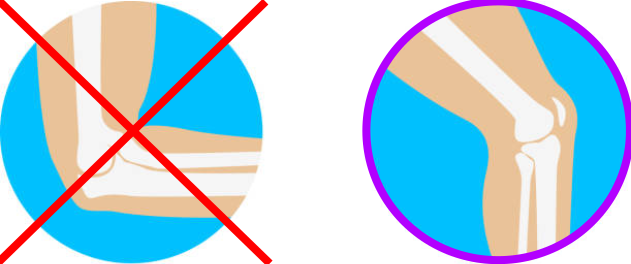

- To draw such plot, we need to **rank the barcodes** thanks to their total counts.

### 7.1.1 Ranking barcodes

- We will use the [**DropletUtils**](https://bioconductor.org/packages/release/bioc/html/DropletUtils.html) package

  ```r
  # h_barcodeRanks

  ## Read the function help page
  ?DropletUtils::barcodeRanks()
  ```

  ```r
  # bcranks

  ## Generate the rank statistics
  bc_rank <- DropletUtils::barcodeRanks(scmat)
  ```

- Check the ranking of barcodes, according to their counts

  ```r
  # bcrank_top

  ## Show a summary of the ranks (ordered for display convenience)
  print(bc_rank[order(bc_rank$rank),])
  ```

  ```
  DataFrame with 147456 rows and 3 columns
                          rank     total    fitted
                     <numeric> <integer> <numeric>
  ATCATGGCAGCCAATT-1         1     21195        NA
  GGGCATCGTAGCTTGT-1         2     18193        NA
  AGTGGGATCTTAACCT-1         3     16966        NA
  GTCGGGTGTGCAGTAG-1         4     16383        NA
  TTAGGCAAGCCGCCTA-1         5     15406        NA
  ...                      ...       ...       ...
  TTGAACGTCAGAGGTG-1    100998         0        NA
  ACGATGTAGTTGTCGT-1    100998         0        NA
  GTCAAGTTCAGTTGAC-1    100998         0        NA
  TCGCGAGGTTGCGCAC-1    100998         0        NA
  TATCTCAGTTACCAGT-1    100998         0        NA
  ```

### 7.1.2 Kneeplot

Now, we can **draw** our kneeplot :

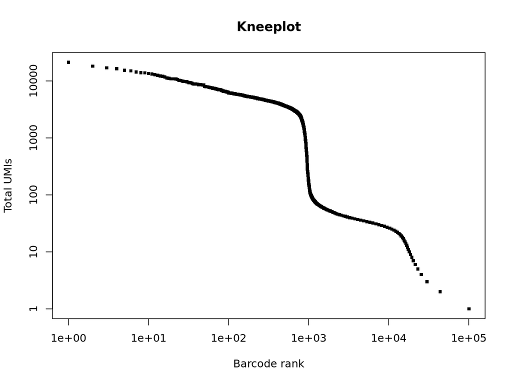

```r
# kneeplot1

## Plot
graphics::plot(x = bc_rank$rank,
               y = bc_rank$total + 1,
               log = "xy",
               xlab = "Barcode rank",
               ylab = "Total UMIs",
               col = "black",
               pch = ".",
               cex = 5,
               main = "Kneeplot")
```

- **Question** :

  ```r
  # q_knee

  Looking at the kneeplot, can you roughly predict how many barcodes will be
  kept as cells (ie, as non-empty droplets) ?
  ```

  ```r
  # a_knee

  ## . The "cliff" in the kneeplot is at a
  ##  rank value a bit below ~ 1,000.
  ```

Then, we can use these ranks to **identify “true” cells** :

```r
# h_emptyDrops

## Read the function help page
?DropletUtils::emptyDrops
```

The function we will use relies on random number generation, so we will fix the RNG seed, for reproducibility

```r
# emptydrops1

## Set the RNG seed
set.seed(my_seed)

## Identify empty droplets
bc_rank2 <- DropletUtils::emptyDrops(scmat)

## Whats is the structure of the returned output ?
str(bc_rank2)
```

**Show output**

```
Formal class 'DFrame' [package "S4Vectors"] with 6 slots
  ..@ rownames       : chr [1:147456] "TCCCGATAGCCTTGAT-1" "AGATCTGAGACTGTAA-1" "GCTTGAAGTGCGAAAC-1" "ATCATGGGTATTCGTG-1" ...
  ..@ nrows          : int 147456
  ..@ elementType    : chr "ANY"
  ..@ elementMetadata: NULL
  ..@ metadata       :List of 5
  .. ..$ lower  : num 100
  .. ..$ niters : num 10000
  .. ..$ ambient: num [1:16738, 1] 8.43e-07 3.38e-05 9.91e-06 8.43e-07 8.43e-07 ...
  .. .. ..- attr(*, "dimnames")=List of 2
  .. .. .. ..$ : chr [1:16738] "RP11-34P13.7" "FO538757.2" "AP006222.2" "RP4-669L17.10" ...
  .. .. .. ..$ : NULL
  .. ..$ alpha  : num 4171
  .. ..$ retain : num 2611
  ..@ listData       :List of 5
  .. ..$ Total  : int [1:147456] 0 0 0 0 0 6 1 1 0 0 ...
  .. ..$ LogProb: num [1:147456] NA NA NA NA NA NA NA NA NA NA ...
  .. ..$ PValue : num [1:147456] NA NA NA NA NA NA NA NA NA NA ...
  .. ..$ Limited: logi [1:147456] NA NA NA NA NA NA ...
  .. ..$ FDR    : num [1:147456] NA NA NA NA NA NA NA NA NA NA ...
```

We can show a summary of the ordered barcodes :

```r
# emptysmry

## Show a summary of the qualified ranks (ordered for display convenience)
print(bc_rank2[order(bc_rank2$Total, decreasing = TRUE),])
```

**Show output**

```
DataFrame with 147456 rows and 5 columns
                       Total   LogProb    PValue   Limited       FDR
                   <integer> <numeric> <numeric> <logical> <numeric>
ATCATGGCAGCCAATT-1     21195  -13101.3 9.999e-05      TRUE         0
GGGCATCGTAGCTTGT-1     18193  -12055.5 9.999e-05      TRUE         0
AGTGGGATCTTAACCT-1     16966  -11594.8 9.999e-05      TRUE         0
GTCGGGTGTGCAGTAG-1     16383  -11994.6 9.999e-05      TRUE         0
TTAGGCAAGCCGCCTA-1     15406  -10687.9 9.999e-05      TRUE         0
...                      ...       ...       ...       ...       ...
TTGAACGTCAGAGGTG-1         0        NA        NA        NA        NA
ACGATGTAGTTGTCGT-1         0        NA        NA        NA        NA
GTCAAGTTCAGTTGAC-1         0        NA        NA        NA        NA
TCGCGAGGTTGCGCAC-1         0        NA        NA        NA        NA
TATCTCAGTTACCAGT-1         0        NA        NA        NA        NA
```

### 7.1.3 Selection

Barcodes considered as empty droplets have **no p-value** (`FDR` = NA)

```r
# bcr2_na

## Creating a validation column (empty droplets have NA as p-value)
bc_rank2$VALID <- !is.na(bc_rank2$FDR)

## Quantify "real cells"
table(bc_rank2$VALID)
```

**Show output**

```
 FALSE   TRUE
146397   1059
```

We can **control the stringency** by setting a FDR-adjusted p-value **threshold**

```r
# valid_fdr

## Recall the max p-value we set as a variable early on
max_p
```

**Show output**

```
[1] 0.001
```

```r
## We've set the max p-value to 1E-03
bc_rank2$VALID[bc_rank2$FDR >= max_p] <- FALSE

## Control
table(bc_rank2$VALID)
```

**Show output**

```
 FALSE   TRUE
146581    875
```

Now, we can **display** our **true cells** on the kneeplot :

```r
# kneeplot2

## Plot with highlight of the selected barcodes (red)
graphics::plot(x = bc_rank$rank,
               y = bc_rank$total+1,
               log = "xy",
               xlab = "Barcode rank",
               ylab = "Total UMIs",
               col = ifelse(bc_rank2$VALID, "red", "black"),
               pch = ".",
               cex = ifelse(bc_rank2$VALID, 7, 3),
               main = paste0("Kneeplot (",
                             length(which(bc_rank2$VALID)),
                             " barcodes kept)"))
```

**Show plot**

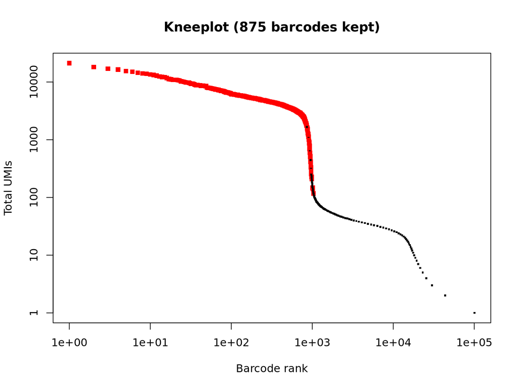

- **Question** :

  ```r
  # q_kneered

  Is there something unexpected for the retained "TRUE" cells (red) in this kneeplot ?
  ```

  ```r
  # a_kneered

  ## . You may observe that the selection of "true" cells (red)
  ##   does not strictly correspond to a "cut" in the kneeplot
  ##   descending curve.
  ##
  ## . This is because emptyDrops does not only "follow" the curve
  ##   to determine a threshold corresponding to a "minimal count"
  ##   value to consider a barcode as a cell, but also performs a
  ##   statistical analysis for each barcode, considering how much
  ##   its expression profile ressembles the one of other cells,
  ##   even with a very different (lower) global level of expression.
  ```

## 7.2 Removal

We just need to restrict our count matrix to “true” cells.

- How many barcodes do we have at the moment ?

  ```r
  # scdim3

  dim(scmat)
  ```

  **Show output**

  ```
  [1]  33694 147456
  ```

- Filter empty droplets out :

  ```r
  # edfilter

  ## Restrict to valid barcodes
  scmat_cells <- scmat[, bc_rank2$VALID]

  ## Control
  dim(scmat_cells)
  ```

  **Show output**

  ```
  [1] 33694   875
  ```

# 8 Ambient RNA

- The counts measured in this matrix of (now considered “true”) single cells do **not** reflect the measurement of these cells expression **only**
- Due to other **over-lysed / dying cells** in the emulsion, we also measured fraction of **ambient RNA** that adds up to the “real” expression
- We may **estimate** it by observing counts existing at a **minimal level** across cells that greatly differ in their expression profile
- Just in case, due to the fun tool name we will use, `SoupX`, I’ll write down “soup” as an alias for “ambient RNA”, but both terms have the same meaning.

## 8.1 Estimate the “soup”

[**SoupX**](https://cran.r-project.org/web/packages/SoupX/readme/README.html) can estimate the rate and composition of ambient RNA, in several ways :

- **Manual mode** : providing a list of features expected to reflect the soup (genes expressed at high levels in a majority of the expected cell types)
- **Automatic modes**, using the empty droplets-**filtered** raw count matrix …
  - … along **with the unfiltered** matrix (ie, containing all quantified droplets). This is the most efficient mode.
  - … **solely** : this is less efficient, but useful when the unfiltered matrix is not available.

```r
# h_SoupX_auto

## Reading the SoupX package main help page
?SoupX::SoupX
```

Let’s run SoupX, just asking for an estimation of the “soup” proportion :

```r
# soupxrhoE

## TIP : In case of error :
# install.packages("irlba", type="source", force=TRUE)

## SoupX for ambient fraction estimation
soup_frac <- SoupX_auto(
  scmat_filt = scmat_cells,
  scmat_raw = scmat)
```

**Show output**

```
Soup-contributing features (Top 20) :


|       |       est| counts|
|:------|---------:|------:|
|MALAT1 | 0.0321703|  17473|
|B2M    | 0.0194002|  10537|
|TMSB4X | 0.0165850|   9008|
|EEF1A1 | 0.0129267|   7021|
|RPL21  | 0.0103251|   5608|
|RPS27  | 0.0100269|   5446|
|RPL13  | 0.0091542|   4972|
|RPL13A | 0.0087252|   4739|
|RPL10  | 0.0082852|   4500|
|RPLP1  | 0.0079225|   4303|
|RPL34  | 0.0078801|   4280|
|RPS12  | 0.0076481|   4154|
|RPS6   | 0.0075211|   4085|
|RPS18  | 0.0074530|   4048|
|RPS27A | 0.0073093|   3970|
|RPS2   | 0.0072965|   3963|
|RPS3A  | 0.0072909|   3960|
|RPL32  | 0.0072744|   3951|
|RPL41  | 0.0067865|   3686|
|RPL11  | 0.0063446|   3446|
```

*NOTE* : We can observe [**MALAT1**](https://www.biorxiv.org/content/10.1101/2024.07.14.603469v2) as the top first gene (as well as multiple riboprotein-coding genes).

What’s the estimated fraction of soup in our counts ?

```r
# soupxfrac

cat("Soup fraction : ", soup_frac)
```

**Show output**

```
Soup fraction :  0.054
```

- **Question** :

  ```r
  # q_souprate

  Should we try to remove such an amount of ambient RNA ?
  ```

  ```r
  # a_souprate

  The best way to know is to try it out =D
  ```

## 8.2 Remove the “soup”

SoupX can **remove** the soup (subtract counts for identified soup genes to all barcodes/cells) using different methods :

- **Automatically** (safer)
- Specifying a **fraction of counts** to remove.
  - *Pros* :
    - By removing X % of reads :
      - if soup was effectively present (at a rate <= X), this will **mostly affect soup** genes first.
      - If not, it will **decrease counts** globally, thus have negligible effect in differences between cells / cell types.
  - *Cons* :
    - **Counts are** already **rare** in droplet-based single cell technologies… Removing them “by default” makes them **even more rare**…
    - If actual soup **rate is higher** than the defined rate X to remove, this mode will remain **uneffective**…

```r
# soupxrm

## Run SoupX in "removal" mode
scmat_unsoup <- SoupX_auto(
  scmat_filt = scmat_cells,
  scmat_raw = scmat,
  return_object = TRUE)
```

**Show output**

```
Counts BEFORE SoupX :  3766216
```

**Show output**

```
Counts AFTER SoupX :  3563040
```

## 8.3 Effect of the “soup” removal

- Now, we want to **characterize the effect** of the removal of the ambient RNA, by comparing the pre- and post- soupX matrices.
- An easy way is to **describe**, then **visualize** such an effect.

### 8.3.1 Describe and visualize

#### 8.3.1.1 Before SoupX (DEMO)

We can describe our count matrix thanks to some useful metrics :

- Total counts

```r
# descBS_totcount

## All counts
base::sum(scmat_cells)
```

**Show output**

```
[1] 3766216
```

- Sparsity (fraction of `0`s)

```r
# descBS_sparsity

## Compute sparsity (number of matrix values at 0 / cross-product of matrix dim)
base::sum(sparseMatrixStats::colCounts(
  x = scmat_cells, value = 0)
  ) / base::prod(dim(scmat_cells))
```

**Show output**

```
[1] 0.9614275
```

- Distribution of counts in cells

```r
# descBS_nCount

## Sums up counts for each cell
base::summary(sparseMatrixStats::colSums2(x = scmat_cells, na.rm = TRUE))
```

**Show output**

```
   Min. 1st Qu.  Median    Mean 3rd Qu.    Max.
    116    3069    3957    4304    5014   21195
```

- Distribution of expressed genes in cells

```r
# descBS_nFeature

## All genes minus 0-count genes
base::summary(nrow(scmat_cells) - sparseMatrixStats::colCounts(
  x = scmat_cells,
  value = 0,
  na.rm = TRUE))
```

**Show output**

```
   Min. 1st Qu.  Median    Mean 3rd Qu.    Max.
     89    1052    1242    1300    1484    3752
```

#### 8.3.1.2 After SoupX

We can describe our count matrix thanks to some useful metrics :

- Total counts

```r
# descAS_totcount

## All counts
base::sum(scmat_unsoup)
```

**Show output**

```
[1] 3563040
```

- Sparsity (fraction of `0`s)

```r
# descAS_sparsity

## Compute sparsity (number of matrix values at 0 / cross-product of matrix dim)
base::sum(sparseMatrixStats::colCounts(
  x = scmat_unsoup, value = 0)
  ) / base::prod(dim(scmat_unsoup))
```

**Show output**

```
[1] 0.9635223
```

- Distribution of counts in cells

```r
# descAS_nCount

## Sums up counts for each cell
base::summary(sparseMatrixStats::colSums2(x = scmat_unsoup, na.rm = TRUE))
```

**Show output**

```
   Min. 1st Qu.  Median    Mean 3rd Qu.    Max.
    113    2912    3735    4072    4754   19797
```

- Distribution of expressed genes in cells

```r
# descAS_nFeature

## Compute sparsity (number of matrix values at 0 / cross-product of matrix dim)
base::summary(nrow(scmat_cells) - sparseMatrixStats::colCounts(
  x = scmat_unsoup,
  value = 0,
  na.rm = TRUE))
```

**Show output**

```
   Min. 1st Qu.  Median    Mean 3rd Qu.    Max.
     88    1002    1175    1229    1400    3435
```

- **Questions** :

  ```r
  # q_descdiff

  Can you describe the difference (especially for counts and sparsity) ?

  Was it expected ?
  ```

  ```r
  # a_descdiff

  ## . Total counts, max value, counts per cell and number of
  ##   expressed features per cell, all have decreased.
  ##
  ## . The sparsity level has slightly increased (removing the soup
  ##   obliterated all counts for some features in some cells).
  ##
  ## . All of this is absolutely expected.
  ```

What are the features most affected by the soup removal ?

```r
# soupfeatures

## Compute the fraction matrix (PRE / POST)
##  NOTE : we may have 0 counts in the divider,
##  so we increment both matrix by +1 !
cont_frac <- (scmat_cells + 1) / (scmat_unsoup + 1)

## Fraction of counts decreased by soup removal, per feature (ordered)
feat_frac <- sort(sparseMatrixStats::rowMeans2(cont_frac), decreasing = TRUE)

### Display Top 5 features
utils::head(feat_frac, decreasing = TRUE)
```

**Show output**

```
     LYZ   S100A9   S100A8  HLA-DRA     CD74     CST3
1.478310 1.453317 1.384649 1.343360 1.279586 1.204137
```

```r
## Removing objects to free some RAM
rm(cont_frac, feat_frac)
```

```r
# qsoupfeat

Does something about these genes strike you ?
```

Hint : **fraction** or **difference** ?

```r
# soupfeaturesdiff

## Compute the DIFFERENCE matrix (PRE / POST)
##  NOTE : we may have 0 counts in the divider,
##  so we increment both matrix by +1 !
cont_dif <- scmat_cells - scmat_unsoup

## Fraction of counts decreased by soup removal, per feature (ordered)
feat_dif <- sort(sparseMatrixStats::rowMeans2(cont_dif), decreasing = TRUE)

### Display Top 5 features
utils::head(feat_dif, decreasing = TRUE)
```

**Show output**

```
  MALAT1      B2M   TMSB4X   EEF1A1    RPL21    RPS27
7.533714 4.528000 3.885714 3.060571 2.435429 2.372571
```

```r
## Removing objects to free some RAM
rm(cont_dif, feat_dif)
```

### 8.3.2 Plot the “top 1” feature

We want to visualize the expression of the “top” soup gene, LYZ, in our dataset.

To do so, we will generate a projection of the data into a reduced (2-D) mathematical space. This is done by using a series of R function from the Seurat package, that we won’t describe here and now : understanding these commands below is not the scope of our current session, but it will be during the next few days.

Actually, these commands perform all the steps we’ll see in the next few days, in a row, but with *default values* (thus, almost certainly inadequate to our current data).

In consequence, please just consider the output as a way to quickly and dirtily visualize the data : the depicted topology should be considered as very rough and mostly imperfect.

#### 8.3.2.1 Before SoupX

```r
# bsoupx

## Roll process, using a temporary "sobj_presoupx" Seurat object
sobj_presoupx <- Seurat::CreateSeuratObject(counts = scmat_cells, project = "PBMC10K_BeforeSoupX")
sobj_presoupx <- Seurat::NormalizeData(object = sobj_presoupx, verbose = FALSE)
sobj_presoupx <- Seurat::ScaleData(object = sobj_presoupx, verbose = FALSE)
sobj_presoupx <- Seurat::FindVariableFeatures(object = sobj_presoupx, verbose = FALSE)
sobj_presoupx <- Seurat::RunPCA(object = sobj_presoupx, npcs = 21, verbose = FALSE)
sobj_presoupx <- Seurat::RunUMAP(object = sobj_presoupx, dims = c(1:20), verbose = FALSE)

## Top1 feature plot
fp_pre <- Seurat::FeaturePlot(object = sobj_presoupx, features = 'LYZ') + Seurat::DarkTheme()
print(fp_pre)
```

**Show plot**

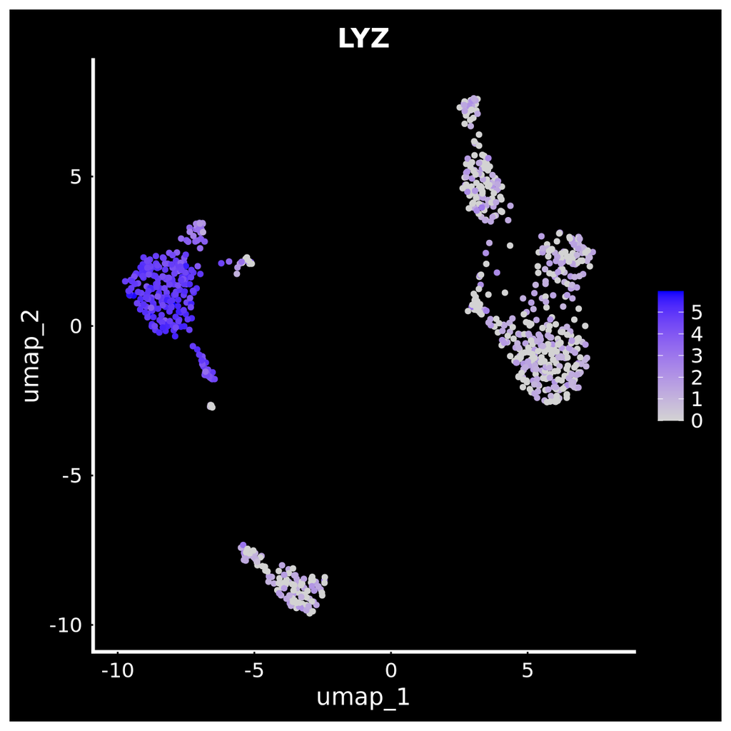

#### 8.3.2.2 After SoupX

```r
# asoupx

## Roll process, using a temporary "sobj_postsoupx" Seurat object
sobj_postsoupx <- Seurat::CreateSeuratObject(counts = scmat_unsoup, project = "PBMC10K_AfterSoupX")
sobj_postsoupx <- Seurat::NormalizeData(object = sobj_postsoupx, verbose = FALSE)
sobj_postsoupx <- Seurat::ScaleData(object = sobj_postsoupx, verbose = FALSE)
sobj_postsoupx <- Seurat::FindVariableFeatures(object = sobj_postsoupx, verbose = FALSE)
sobj_postsoupx <- Seurat::RunPCA(object = sobj_postsoupx, npcs = 21, verbose = FALSE)
sobj_postsoupx <- Seurat::RunUMAP(object = sobj_postsoupx, dims = c(1:20), verbose = FALSE)

## Top1 feature plot
fp_post <- Seurat::FeaturePlot(object = sobj_postsoupx, features = 'LYZ') + Seurat::DarkTheme()
print(fp_post)
```

**Show plot**

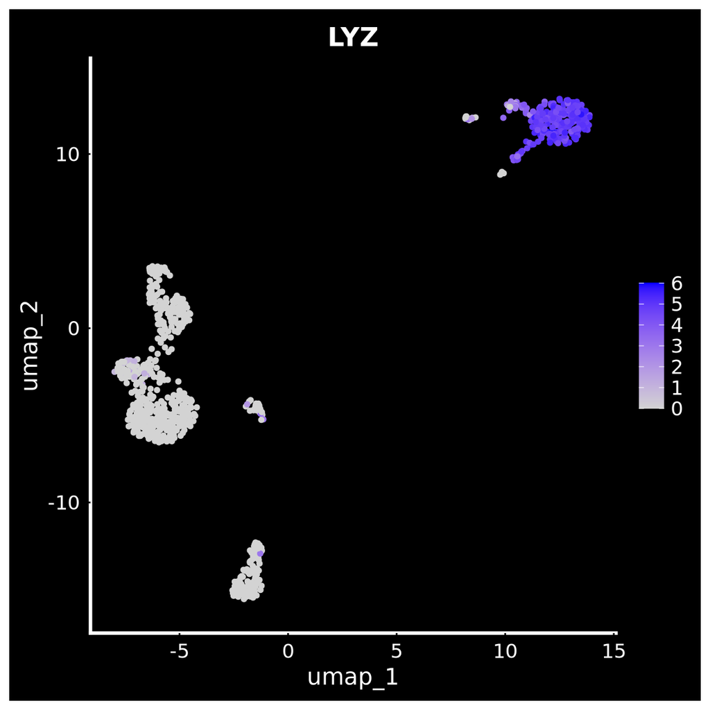

Merging plots for ease of use :

```r
# soupx_umaps

## Using the patchwork package to merge plots (and ggplot2 to add titles)
patchwork::wrap_plots(
  list(
    fp_pre & ggplot2::ggtitle(label = "LYZ before SoupX"),
    fp_post & ggplot2::ggtitle(label = "LYZ after SoupX")),
  nrow = 1)
```

**Show plot**

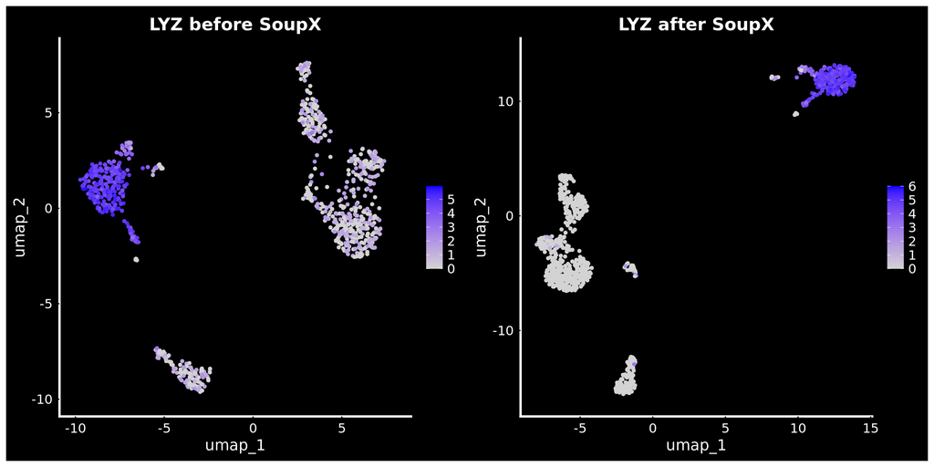

- **Question**

  ```r
  # q_umapsoupx

  Can you compare the two plots :
    - for the LYZ expression across the 2-D space ?
    - about the space topologies ?
    - for the LYZ expression globally ?
  ```

  ```r
  # a_umapsoupx

  ## . The level of expression measured in cells with smaller expression
  ##   before SoupX has gone to almost none after : the ambient expression
  ##   of this gene has efficiently been removed.
  ##
  ## . Hopefully, the cluster(s) with higher expression remain(s) high.
  ##
  ## . The expression scale upper bound after SoupX is higher than before ?!
  ##   But we REMOVED some counts ?! While being counter-intuitive, this is
  ##   a positive consequence of the ambient removal on the scaling of
  ##   barcodes expression (see later).
  ##
  ## . The range of both X and Y axes have increased, depicting a better
  ##   separation of / distance between some of the clusters.
  ##
  ## . The global topology of clusters remains close (but not identical).
  ##
  ## . Clusters compacity has increased.
  ```

## 8.4 Conclusion

- Removing ambient RNA has a **positive effect** :
  - on the **quality of the expression** level measurements
  - on the observed **topology**
  - … despite an estimation of only ~5% !
- Actually, ambient RNA level and composition is (one of) the major source(s) of the **batch effect bias** that may alter the integration of different samples.

**Beyond** :

1. One can check if the “unsouped” (ie, post-SoupX) matrix retain some soup ?. How would you do it ?

   ```r
   # b_soupx2

   ## SoupX for ambient fraction estimation
   soup2_frac <- SoupX_auto(
     scmat_filt = scmat_unsoup,
     scmat_raw = scmat)

   ## Run SoupX in "removal" mode
   scmat_unsoup2 <- SoupX_auto(
     scmat_filt = scmat_unsoup,
     scmat_raw = scmat,
     return_object = TRUE)
   ```

2. Save the `sobj_presoupx` R object on disk.

   ```r
   # b_save_answer1

   ## A single object : use RDS format with saveRDS()
   saveRDS(object = sobj_presoupx, file = paste0(output_dir, "/sobj_presoupx.RDS"))
   ```

3. Save both the `sobj_presoupx` and `sobj_postsoupx` objects in a single archive on disk.

   ```r
   # b_save_answer2

   ## Multiple objects : use Rdata format with save()
   save(list = c(sobj_presoupx, sobj_postsoupx), file = paste0(output_dir, "/sobjects.RDA"))
   ```

   ```r
   # b_save_answer3

   ## Compress with bzip2
   saveRDS(object = sobj, file = paste0(output_dir, "/sobj.RDS"), compress = "bzip2")
   ```

# 9 Rsession

For reproducibility and context, it is recommended to include in your RMarkdown the list of loaded packages and their version.

```r
# rsession

utils::sessionInfo()
```